# Figure 5 - *huva*

Bonaguro et al.

This Rmarkdonwn document can be used to reproduce the panels in figure 5 of the manuscript: *huva: human variation in gene expression as surrogate for gene function*. To run this script without any problem of dependencies or conflicts in the installation we suggest to use the docker image we provide (see README file).

# 1 Figure 5 (Supp. Figures S12, S13, S14)

In this figure we compare the result of the *huva experiment* for STAT1, a key regulator of T cell biology where not much is yet understood about its role in monocytes. We compare the results with the phenotype and transcriptome of STAT1 GOF patients, showing how *huva* can also predict the changes cause by a GOI mutation (HIGH *huva* group)

## 1.1 Loading required packages

```r
library(huva)
library(huva.db)
library(fgsea)
library(ggplot2)
library(tidyr)
library(ggrepel)
library(gplots)
library(ggbeeswarm)
library(reshape2)
library(factoextra)
library(Hmisc)
library(VennDiagram)
library(rhdf5)
library(clusterProfiler)
library(DOSE)
library(GSEABase)
library(RColorBrewer)
library(ComplexHeatmap)
library(tximport)
library(DESeq2)
library(vsn)
library(pheatmap)
library(genefilter)
library(biomaRt)
library(limma)
library(IHW)
library(org.Hs.eg.db)
library(ggsci)
library(ggpubr)
```

## 1.2 Costum Functions

```r
source("./source/costum_function.R")
```

## 1.3 STAT1 *huva experiment*

At first we calculate the *huva experiment* for *STAT1* to investigate the effect of the modulation of this gene in the immune system

### 1.3.1 Run the experiment

```r
set.seed(91)

STAT1_binned <- run_huva_experiment(data = huva.db,
                                      gene = "STAT1",
                                      quantiles = 0.10,
                                      gs_list = hallmarks_V7.2,
                                      summ = T,
                                      datasets_list = NULL,
                                      adjust.method = "BH")
```

### 1.3.2 Principal component analysis

```r
DE_HuVa_FG500 <- get_DE_huva(huva_exp = STAT1_binned, study = "FG500")
```

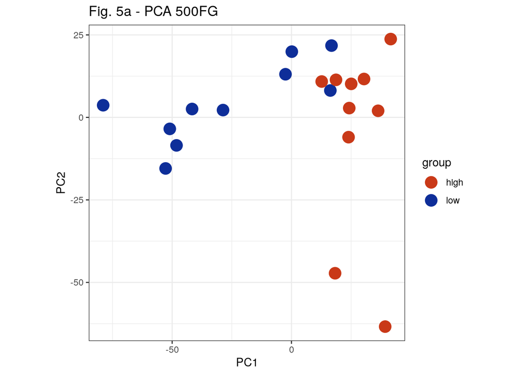

```r
DE_HuVa_FG500$PCA_FG500_PBMC + ggtitle("Fig. 5a - PCA 500FG")
```

### 1.3.3 Number of DE genes

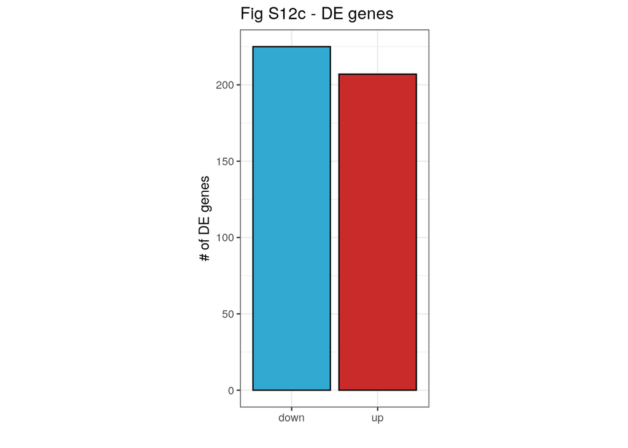

```r
DE_table <- STAT1_binned$FG500$DE_genes$FG500_PBMC

DE_table$reg <- ifelse(DE_table$logFC < -1 & DE_table$adj.P.Val < 0.05, "down",
                       ifelse(DE_table$logFC > 1 & DE_table$adj.P.Val < 0.05, "up", "none"))

tmp <- as.data.frame(table(DE_table$reg))
tmp <- tmp[tmp$Var1 %in% c("up", "down"), ]

ggplot(tmp, aes(x=Var1, y=Freq, fill=Var1)) +
  geom_bar(stat = "identity", color = "black") +
  scale_x_discrete(limits = c("down", "up")) +
  theme_bw() + theme(aspect.ratio = 2, legend.position = "none") +
  scale_fill_manual(values = c("#32A9D1", "#C92A2A")) +
  xlab("") + ylab("# of DE genes") +
  ggtitle("Fig S12c - DE genes")
```

### 1.3.4 GOEA - hallmark

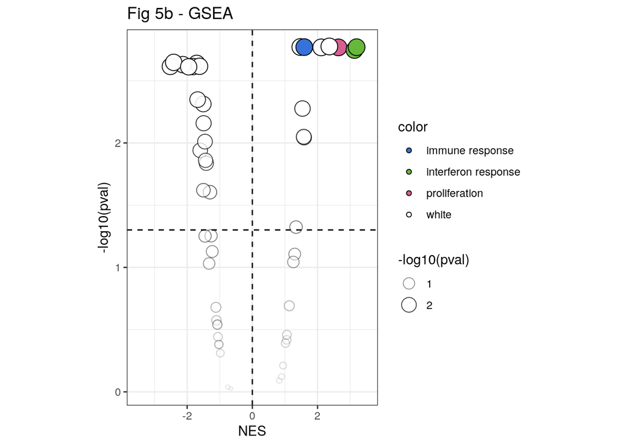

```r
gsea_500FG <- get_gsea_huva(huva_exp = STAT1_binned, study = "FG500")

# Define the color
gsea_500FG$FG500_PBMC$color <- "white"

gsea_500FG$FG500_PBMC$color <- ifelse(gsea_500FG$FG500_PBMC$pathway %in% c("HALLMARK_INTERFERON_ALPHA_RESPONSE", "HALLMARK_INTERFERON_GAMMA_RESPONSE"), "interferon response",
                                      ifelse(gsea_500FG$FG500_PBMC$pathway == "HALLMARK_INFLAMMATORY_RESPONSE", "immune response",
                                            ifelse(gsea_500FG$FG500_PBMC$pathway == "HALLMARK_G2M_CHECKPOINT", "proliferation", "white")))

ggplot(gsea_500FG$FG500_PBMC, aes(x=-NES, y=-log10(pval), size = -log10(pval), alpha=-log10(pval), fill = color)) +
  geom_point(shape=21) + theme_bw() +
  theme(aspect.ratio = 1.5) +
  geom_hline(yintercept = -log10(0.05), linetype = "dashed") +
  geom_vline(xintercept = 0, linetype = "dashed") +
  scale_x_continuous(limits = c(-3.5, 3.5)) +
  scale_fill_manual(values = c("#3672d9", "#66b83b", "#d65e90", "#ffffff")) +
  ggtitle("Fig 5b - GSEA") +
  xlab("NES")
```

### 1.3.5 GSEA - Selected pathway

```r
rank_gene_HuVa <- list()

rank_gene_HuVa$FG500 <- STAT1_binned$FG500$Rank_genelist$FG500_PBMC
```

#### 1.3.5.1 INTERFERON ALPHA RESPONSE

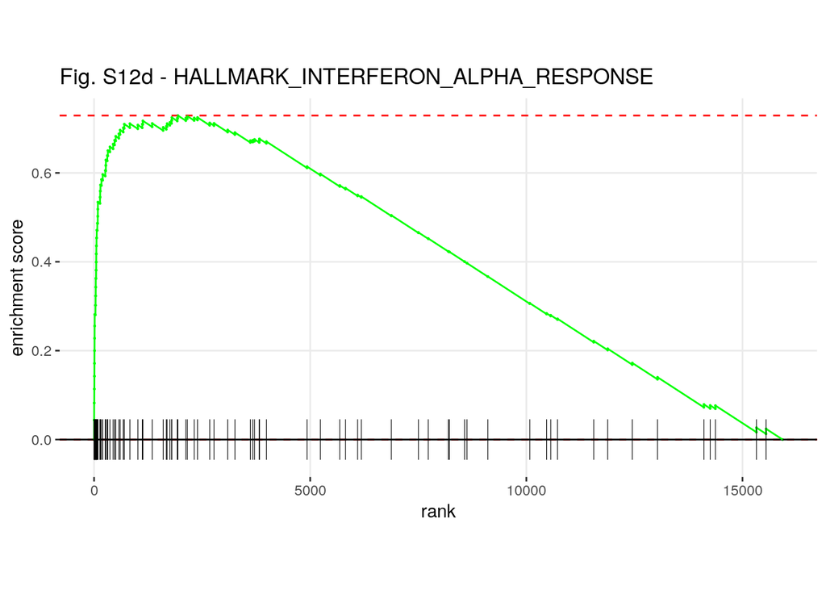

```r
plotEnrichment(hallmarks_V7.2$HALLMARK_INTERFERON_ALPHA_RESPONSE,
               -rank_gene_HuVa$FG500) + labs(title="Fig. S12d - HALLMARK_INTERFERON_ALPHA_RESPONSE") + theme(aspect.ratio = 1/2)
```

#### 1.3.5.2 INTERFERON GAMMA RESPONSE

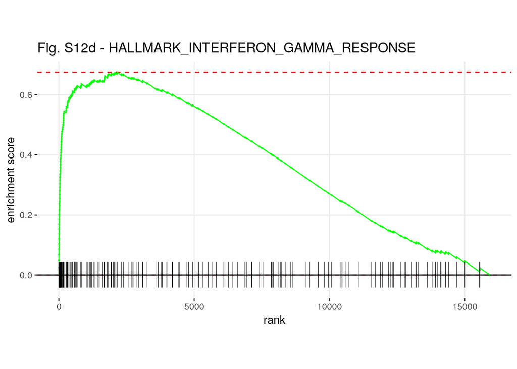

```r
plotEnrichment(hallmarks_V7.2$HALLMARK_INTERFERON_GAMMA_RESPONSE,
               -rank_gene_HuVa$FG500) + labs(title="Fig. S12d - HALLMARK_INTERFERON_GAMMA_RESPONSE") + theme(aspect.ratio = 1/2)
```

#### 1.3.5.3 G2M CHECKPOINT

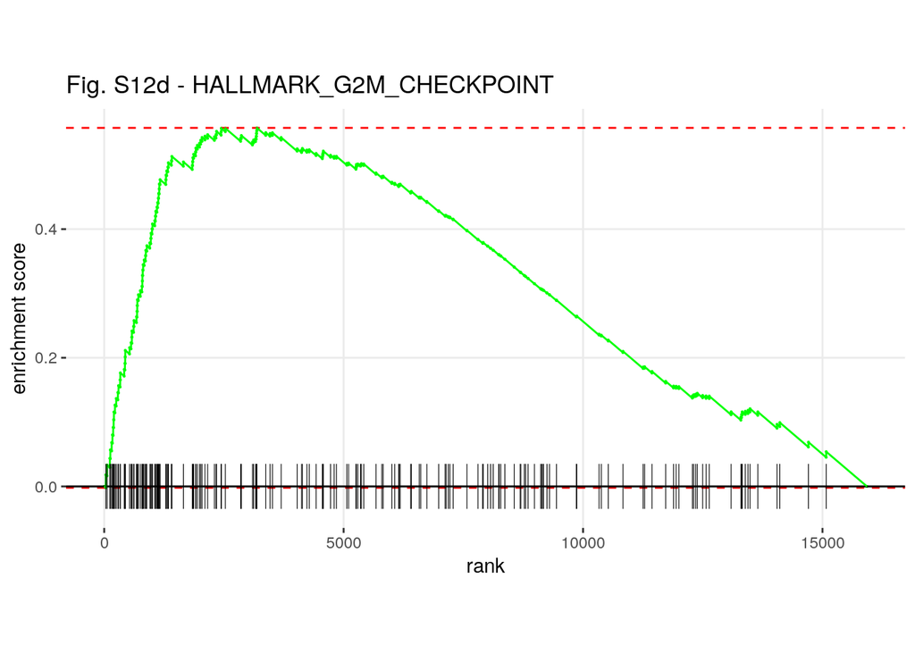

```r
plotEnrichment(hallmarks_V7.2$HALLMARK_G2M_CHECKPOINT,
               -rank_gene_HuVa$FG500) + labs(title="Fig. S12d - HALLMARK_G2M_CHECKPOINT") + theme(aspect.ratio = 1/2)
```

#### 1.3.5.4 INFLAMMATORY RESPONSE

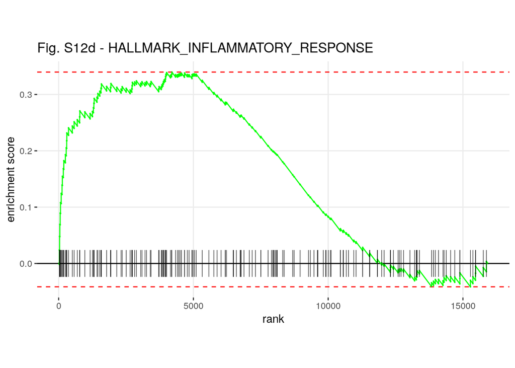

```r
plotEnrichment(hallmarks_V7.2$HALLMARK_INFLAMMATORY_RESPONSE,
               -rank_gene_HuVa$FG500) + labs(title="Fig. S12d - HALLMARK_INFLAMMATORY_RESPONSE") + theme(aspect.ratio = 1/2)
```

### 1.3.6 Changes in cell counts and cytokines

```r
meta.plot_FG500 <- get_meta.plot_huva(huva_exp = STAT1_binned, study = "FG500")
```

#### 1.3.6.1 Monocytes

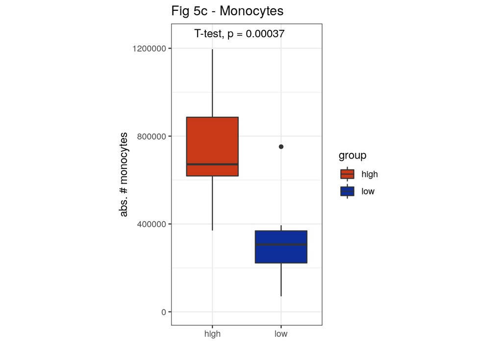

```r
meta.plot_FG500$FG500_PBMC_cellcount$`Monocytes (CD14+)` +
  scale_y_continuous(limits = c(0, 1250000)) +
  theme_bw() +
  theme(aspect.ratio = 2) +
  ggtitle("Fig 5c - Monocytes") +
  ylab("abs. # monocytes")
```

#### 1.3.6.2 Classical Monocytes

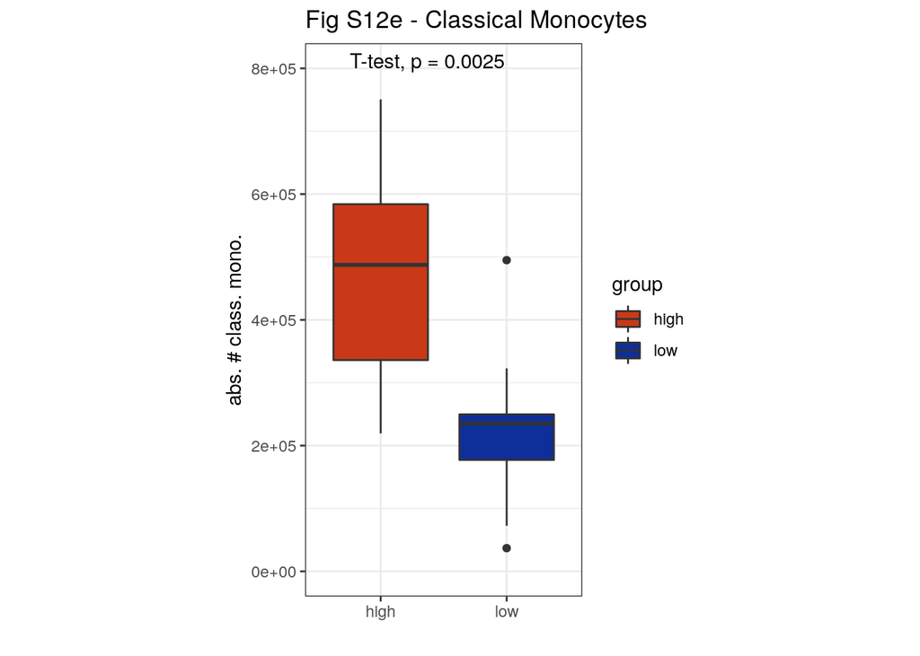

```r
meta.plot_FG500$FG500_PBMC_cellcount$`Classical monocytes (CD14++CD16-)` +
  scale_y_continuous(limits = c(0, 800000)) +
  theme_bw() +
  theme(aspect.ratio = 2) +
  ggtitle("Fig S12e - Classical Monocytes") +
  ylab("abs. # class. mono.")
```

#### 1.3.6.3 Intermediate Monocytes

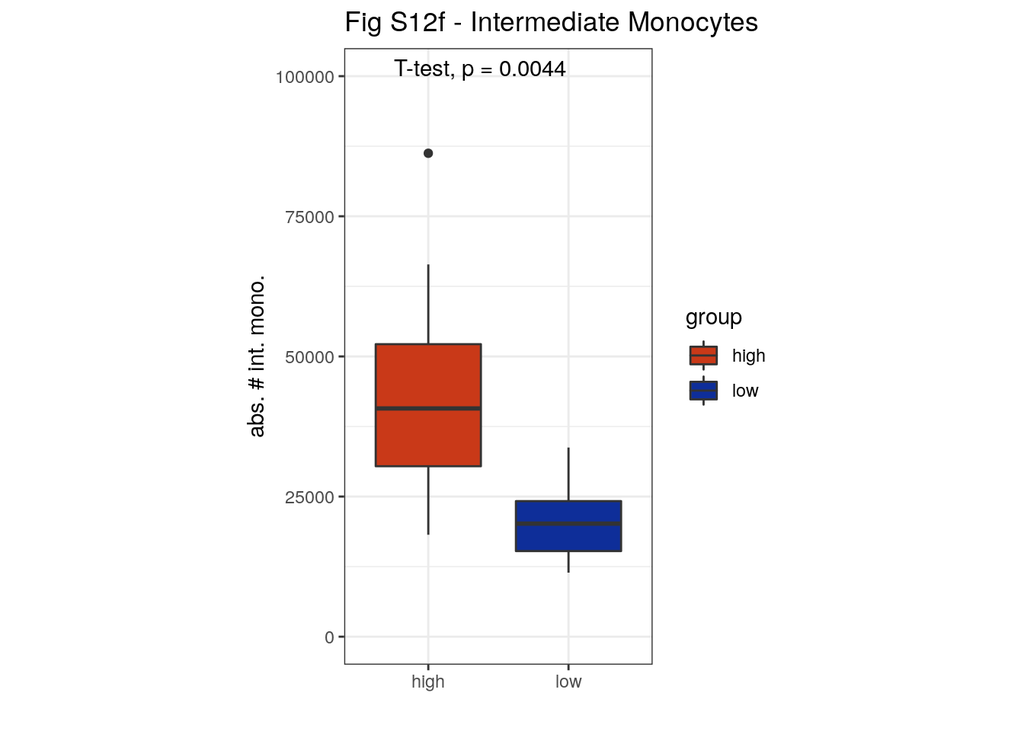

```r
meta.plot_FG500$FG500_PBMC_cellcount$`Intermediate monocytes (CD14+CD16+)` +
  scale_y_continuous(limits = c(0, 100000)) +
  theme_bw() +
  theme(aspect.ratio = 2) +
  ggtitle("Fig S12f - Intermediate Monocytes") +
  ylab("abs. # int. mono.")
```

#### 1.3.6.4 Non-classical Monocytes

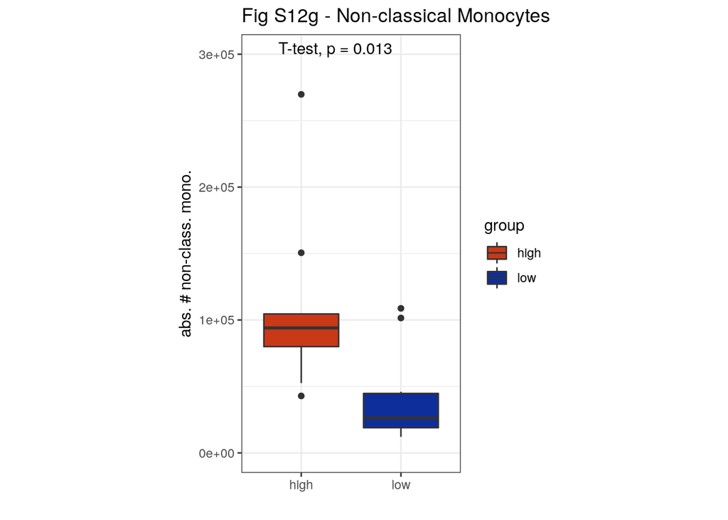

```r
meta.plot_FG500$FG500_PBMC_cellcount$`Non-classical monocytes (CD14++CD16+)` +
  scale_y_continuous(limits = c(0, 300000)) +
  theme_bw() +
  theme(aspect.ratio = 2) +
  ggtitle("Fig S12g - Non-classical Monocytes") +
  ylab("abs. # non-class. mono.")
```

#### 1.3.6.5 IL1b

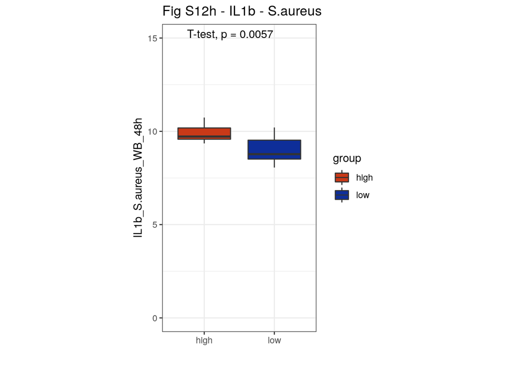

```r
meta.plot_FG500$FG500_PBMC_cytokines$IL1b_S.aureus_WB_48h +
  scale_y_continuous(limits = c(0, 15)) +
  theme_bw() +
  theme(aspect.ratio = 2) +
  ggtitle("Fig S12h - IL1b - S.aureus")
```

## 1.4 STAT1 GOF

To validate the results of the *huva experimet* here we investigate the changes in the immune system in patients with a GOF mutation for *STAT1*. We will first perform a differential expression analysis comparing GOF patients with age matched controls to later compare this result with the result of the *huva expreiment* in both whole blood and monocytes samples.

### 1.4.1 Load the data

Loading the data for the analysis (expression and annotation table).

```r
STAT1_counts <- readRDS("./data/STAT1_counts.rds")

sample_table <- readRDS("./data/sample_table.rds")

identical(colnames(STAT1_counts), rownames(sample_table))
```

```
## [1] TRUE
```

### 1.4.2 Parameters

Setting the parameters for the analysis.

```r
organism = "human"

dir <- "."

plot_order <- "Group"

plot_annotation <- sample_table[,c("Group"), drop = F]
```

### 1.4.3 Color scheme

Setting the color scheme for the analysis.

```r
# Candida.stimulation
col_Candida.stimulation <- c("#0FBA23")
names(col_Candida.stimulation) <- c("Unstimulated")
# Candida.stimulation.1
col_Candida.stimulation.1 <- c("#CD1076")
names(col_Candida.stimulation.1) <- c("4")
# STAT1.mutation
col_STAT1.mutation = c("#00FFFF", "#FFB90F", "#EEAD0E","#CD950C")
names(col_STAT1.mutation) <- c("none", "p.R274W", "p.R274Q",    "p.D23V")
# CMC.patient
col_CMC.patient <- c("#CDC0B0", "#8B8378")
names(col_CMC.patient) <- c("Control", "CMC Patient")
# Group
col_Group <- c("#A0DB8E","#FF4500")
names(col_Group) <- c("ctrl_4h_unstim","pat_4h_unstim")
#Candida.stimulation.2
col_Candida.stimulation.2 <- c(brewer.pal(4, "Greens"))
names(col_Candida.stimulation.2) <- c("Yes (4 Hours)", "No (4 Hours)","Yes (24 Hours)","No (24 Hours)")
#Experiment.date
col_Date <- c(brewer.pal(3, "Reds"))
names(col_Date) <- c("Feb_12","Jul_12","Dec_13")
#Sex
col_Sex<- c("#596E78","#CC99A2")
names(col_Sex) <- c("F","M")

# combine color code into list
ann_colors <- list(Group = col_Group,
                   Candida.stimulation = col_Candida.stimulation,
                   Candida.stimulation.1 = col_Candida.stimulation.1,
                   STAT1.mutation = col_STAT1.mutation,
                   CMC.patient = col_CMC.patient)
```

### 1.4.4 Preparation of the dds

```r
dds_txi <- DESeqDataSetFromMatrix(countData = STAT1_counts,
                                  colData = sample_table,
                                  design = ~ Group,
                                  ignoreRank=FALSE)
```

#### 1.4.4.1 Filter low count genes

We remove all gene with low expression, in this case we remove all the genes with a total expression of 100 considering the depth of sequencing of the data.

```r
genes_to_keep <- rowSums(counts(dds_txi)) >= 100
dds <- dds_txi[genes_to_keep,]
```

### 1.4.5 DEseq2

```r
dds <- DESeq(dds)
```

### 1.4.6 Normalized count table

Export a normalized count table of the data with some extra information on the genes

```r
tx_annotation <- read.delim(file.path("./reference_files/ID2SYMBOL_gencode_v27_transcript.txt"),
                         header = F ,
                         stringsAsFactors = F,
                         col.names = c("GENEID", "TXNAME", "SYMBOL", "GENETYPE"))

norm_anno <- as.data.frame(counts(dds, normalized=T))
norm_anno$GENEID <- row.names(norm_anno)

# add gene annotation extracted from the gtf file
tx_annotation<-separate(tx_annotation, col=GENEID, into=c("GENEID","Y"), sep="[.]")
tx_annotation$Y<-NULL
gene_annotation <- tx_annotation[!duplicated(tx_annotation$GENEID),c("GENEID", "SYMBOL", "GENETYPE")]
gene_annotation <- gene_annotation[match(rownames(norm_anno), gene_annotation$GENEID),]

# add additional gene annotation downloaded from biomart
biomart <- read.delim(file.path("./reference_files/biomart_190110.txt"), stringsAsFactors = FALSE)
idx <- match(unlist(lapply(strsplit(gene_annotation$GENEID, split = "[.]"), `[[`, 1)), biomart$Gene.stable.ID)
gene_annotation$DESCRIPTION <- biomart$Gene.description[idx]
gene_annotation$CHR <- biomart$Chromosome.scaffold.name[idx]

# merge expression table and annotation
norm_anno <- merge(norm_anno,
                   gene_annotation,
                   by = "GENEID")

rownames(norm_anno) <- norm_anno$GENEID
```

### 1.4.7 rlog transformation

For data visualization the normalized counts are rlog tranformed

```r
dds_vst <- rlog(dds, blind = TRUE)
```

### 1.4.8 Batch correction

There is a clear batch in the data coming from the experimental data, this information is used to correct the data with the limma funtion and the DESeq2 model.

```r
batch_dds_vst <- limmaBatchEffectRemoval(input=dds_vst,
                                         modelfactor = "Group",
                                         batchfactor = "Date",
                                         batchfactor_2 = NULL)
```

### 1.4.9 PCA

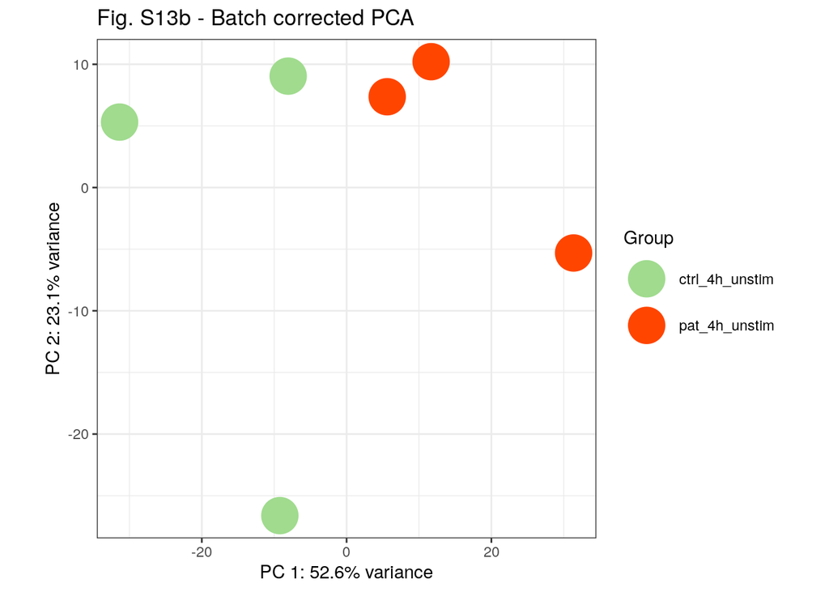

```r
plotPCA(pca_input = batch_dds_vst,
         ntop="all",
         xPC=1,
         yPC=2,
         color="Group",
         anno_colour = col_Group,
         point_size=10, label = NA,
         title="PCA of batch-corrected counts") +
         theme_bw() + theme(aspect.ratio = 1) +
         ggtitle("Fig. S13b - Batch corrected PCA")
```

### 1.4.10 Add the batch in the model

```r
ddssva <- dds
design(ddssva) <- ~ Date + Group

dds <- DESeq(ddssva)
```

```
## found already estimated dispersions, replacing these
```

### 1.4.11 Batch corrected table for visualization

```r
batch_vst_anno <- batch_dds_vst
batch_vst_anno$GENEID <- row.names(batch_vst_anno)

# add gene annotation extracted from the gtf file
gene_annotation <- tx_annotation[!duplicated(tx_annotation$GENEID),c("GENEID", "SYMBOL", "GENETYPE")]
gene_annotation <- gene_annotation[gene_annotation$GENEID %in% rownames(batch_vst_anno) ,]

# add additional gene annotation downloaded from biomart
biomart <- read.delim(file.path("./reference_files/biomart_190110.txt"), stringsAsFactors = FALSE)
idx <- match(unlist(lapply(strsplit(gene_annotation$GENEID, split = "[.]"), `[[`, 1)), biomart$Gene.stable.ID)
gene_annotation$DESCRIPTION <- biomart$Gene.description[idx]
gene_annotation$CHR <- biomart$Chromosome.scaffold.name[idx]

# merge expression table and annotation
batch_vst_anno <- merge(batch_vst_anno,
                   gene_annotation,
                   by = "GENEID")
rownames(batch_vst_anno) <- batch_vst_anno$GENEID
```

### 1.4.12 Calculated differential expression

```r
comparison_table<-data.frame(comparison = c("pat_4h_unstim"),
                             control = c("ctrl_4h_unstim"))

DEresults <- DEAnalysis(condition = "Group",
                        alpha=0.05 ,
                        lfcThreshold= 0,
                        sigFC = 2,
                        multiple_testing="IHW",
                        shrinkage = TRUE,
                        shrinkType="normal")
```

```
## using 'normal' for LFC shrinkage, the Normal prior from Love et al (2014).
##
## Note that type='apeglm' and type='ashr' have shown to have less bias than type='normal'.
## See ?lfcShrink for more details on shrinkage type, and the DESeq2 vignette.
## Reference: https://doi.org/10.1093/bioinformatics/bty895
```

#### 1.4.12.1 Summary

```r
DEcounts <- NULL

for(i in 1:nrow(comparison_table)){
  tmp <- unlist(DEresults[[1+i]]@Number_DE_genes)
  DEcounts <- rbind(DEcounts, tmp)
}

rownames(DEcounts) <- names(DEresults)[-1]

DEcounts
```

```
##                                 up_regulated_Genes down_regulated_Genes
## pat_4h_unstim_vs_ctrl_4h_unstim                146                   57
```

### 1.4.13 STAT1 expression

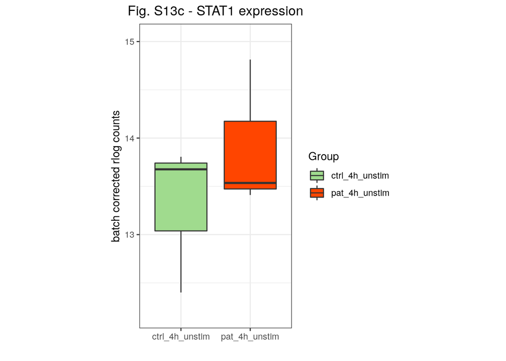

```r
plotSingleGene(data=batch_vst_anno,
                 symbol="STAT1",
                 condition="Group",
                 anno_fill=col_Group,
                 shape= NULL) +
                 theme(aspect.ratio=2) +
                 ggtitle("Fig. S13c - STAT1 expression") +
                 ylab("batch corrected rlog counts") + xlab("")
```

### 1.4.14 HM of DE genes

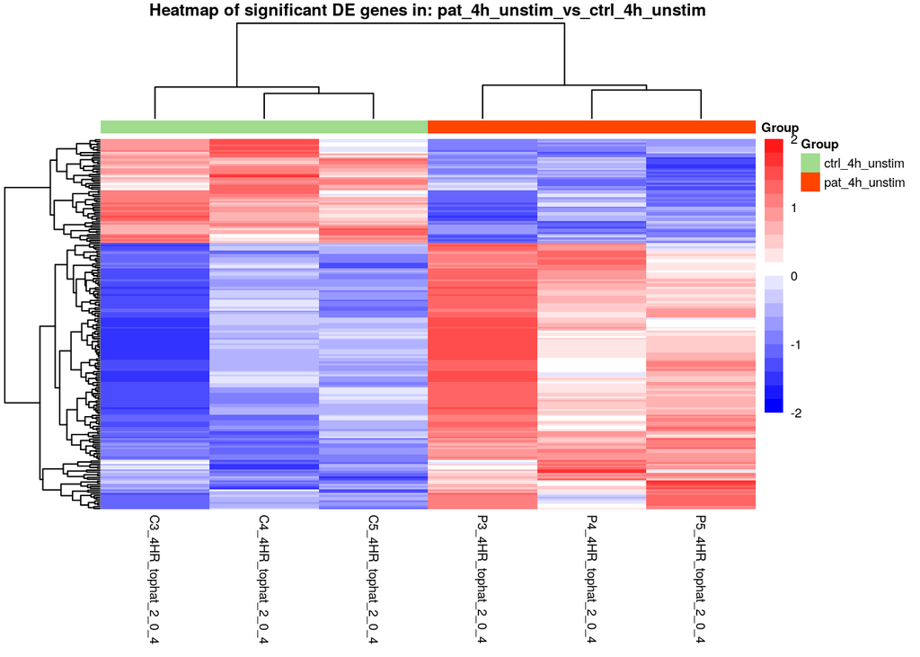

```r
plotDEHeatmap("pat_4h_unstim_vs_ctrl_4h_unstim", data_input = batch_vst_anno,
              factor="Genotype_Age",
              conditions="all", cluster_cols = T)
```

### 1.4.15 Volcano plot

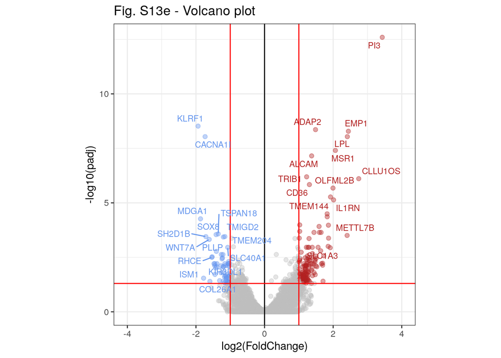

```r
plotVolcano(comparison= "pat_4h_unstim_vs_ctrl_4h_unstim",
            labelnum=10) + scale_x_continuous(limits = c(-4,+4)) + theme(aspect.ratio = 1) +
            ggtitle("Fig. S13e - Volcano plot")
```

### 1.4.16 GOEA

```r
# define universe
universe <- as.character(norm_anno$SYMBOL)
# change symbols to ENTREZ IDs (necessary for ClusterProfiler)
universe_Entrez <- bitr(universe,
                        fromType="SYMBOL",
                        toType="ENTREZID",
                        OrgDb="org.Hs.eg.db")$ENTREZID
GSEA_ctrl_unstim <-  GSEA(comparison="pat_4h_unstim_vs_ctrl_4h_unstim",
                                 organism="human",
                                 GeneSets = c("GO"),
                                 GOntology = "BP",
                                 pCorrection = "none",
                                 pvalueCutoff = 1,
                                 qvalueCutoff = 1)
```

#### 1.4.16.1 Plot

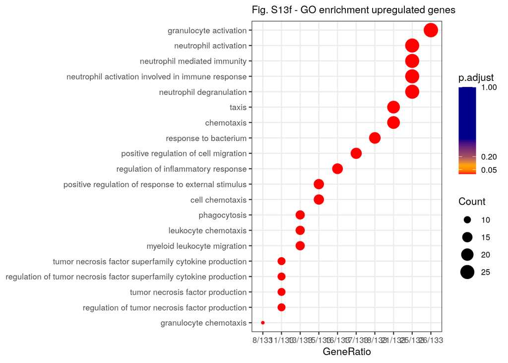

```r
dotplotGSEA(GSEA_ctrl_unstim$GOup, show = 20) + ggtitle("Fig. S13f - GO enrichment upregulated genes")
```

### 1.4.17 Comparison of single genes

We compare the expression of selected STAT1 targets between the result of the *huva expreiment* end the the differential expression analysis of control and STAT1 GOF samples.

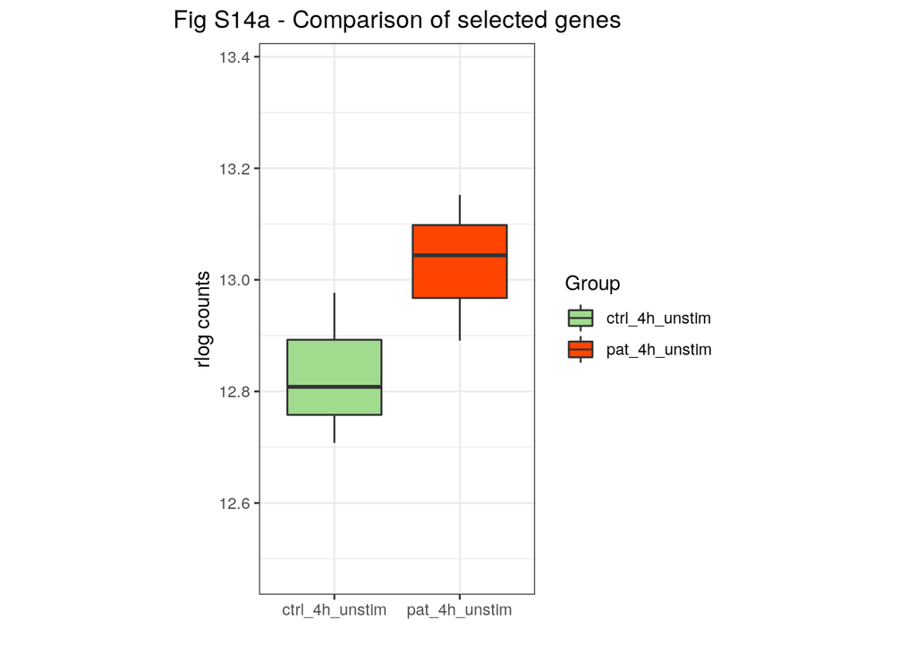

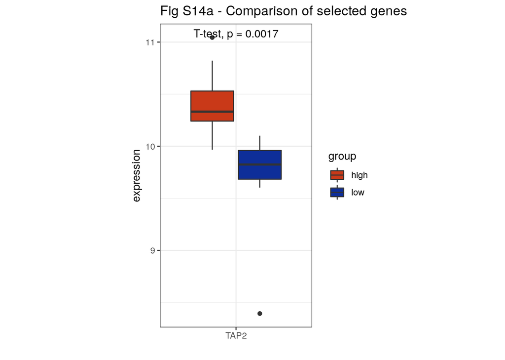

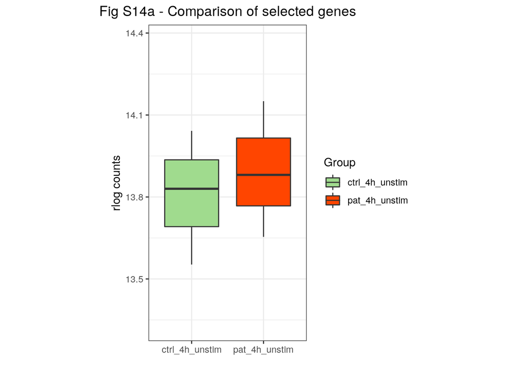

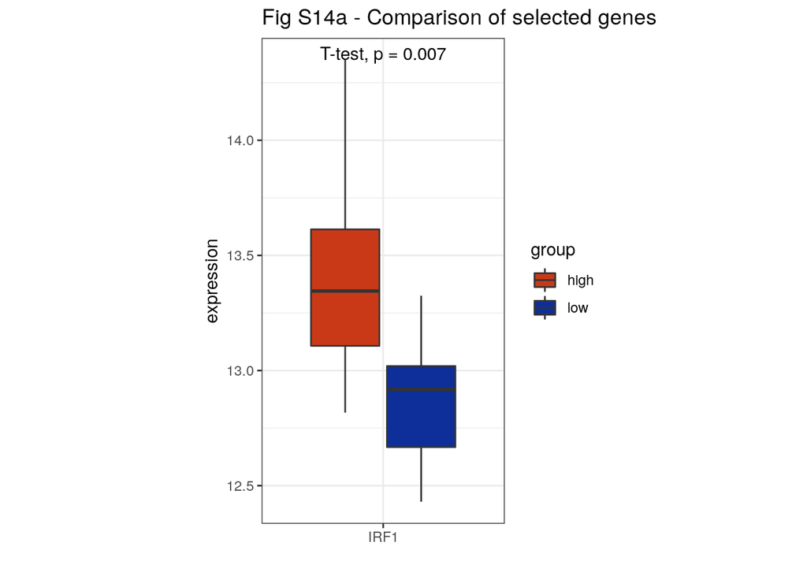

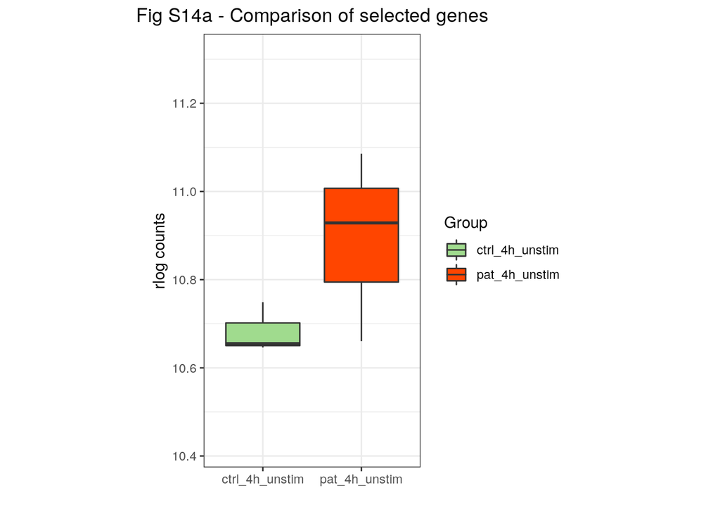

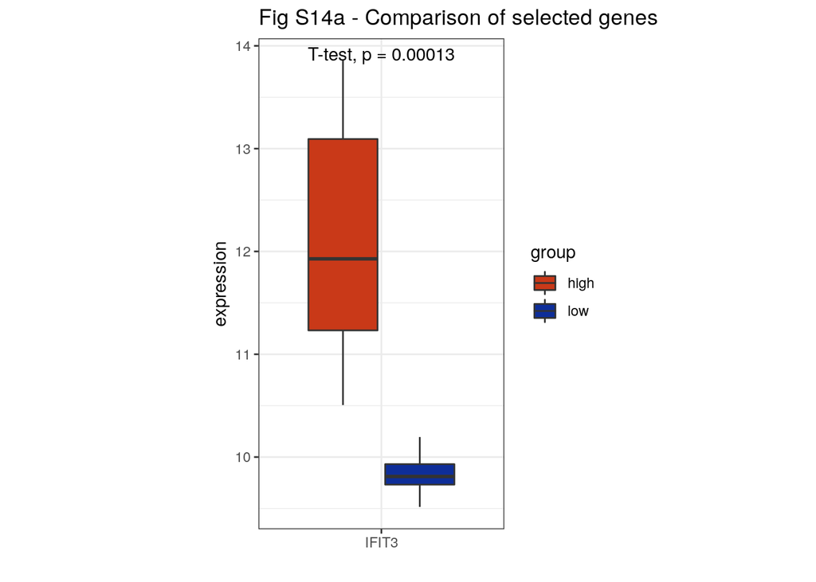

```r
genes <- c("TAP2","IRF1","IFIT3")

for (i in genes) {
 plot <- plotSingleGene(data=batch_vst_anno,
                 symbol=i,
                 condition="Group",
                 anno_fill=col_Group,
                 shape= NULL) + theme(aspect.ratio = 2) +
                 ggtitle("Fig S14a - Comparison of selected genes") +
                 ylab("rlog counts") + xlab("")
 print(plot)

 plot_binned <- plot_binned_gene(goi = i, huva_experiment = STAT1_binned)

 print(plot_binned$FG500_PBMC + theme_bw() + theme(aspect.ratio = 2) + ggtitle("Fig S14a - Comparison of selected genes"))
}
```

### 1.4.18 Comparison of gene signatures

```r
DE_genes_list <- list()

DE_genes_list$up_4h_ctrl <- DEresults$pat_4h_unstim_vs_ctrl_4h_unstim@DE_genes$up_regulated_Genes$SYMBOL
DE_genes_list$dw_4h_ctrl <- DEresults$pat_4h_unstim_vs_ctrl_4h_unstim@DE_genes$down_regulated_Genes$SYMBOL

rank_gene_HuVa <- list()

rank_gene_HuVa$FG500 <- STAT1_binned$FG500$Rank_genelist$FG500_PBMC
rank_gene_HuVa$ImmVarM <- STAT1_binned$ImmVar$Rank_genelist$ImmVar_CD14M

set.seed(91)

gsea_FG500 <- fgsea(pathways = DE_genes_list,
                  stats = -rank_gene_HuVa$FG500,
                  minSize=1,
                  maxSize=Inf,
                  nperm=10000)

set.seed(91)

gsea_ImmVarM <- fgsea(pathways = DE_genes_list,
                  stats = -rank_gene_HuVa$ImmVarM,
                  minSize=1,
                  maxSize=Inf,
                  nperm=10000)
```

#### 1.4.18.1 500FG

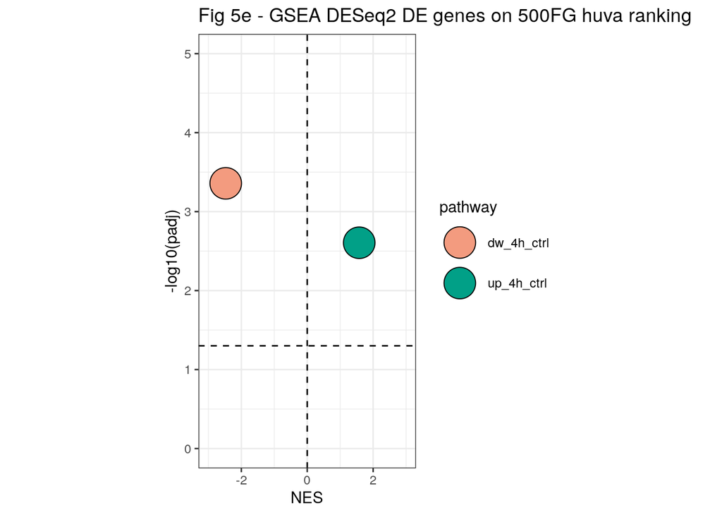

```r
ggplot(gsea_FG500[c(1,2),], aes(x=NES, y=-log10(padj), fill=pathway)) +
  theme_bw() +
  geom_point(size=10, shape =21) +
  theme(aspect.ratio = 2) +
  scale_x_continuous(limits = c(-3,3)) +
  scale_y_continuous(limits = c(0,5)) +
  geom_hline(yintercept = -log10(0.05), linetype="dashed") +
  geom_vline(xintercept = 0, linetype="dashed") +
  ggtitle("Fig 5e - GSEA DESeq2 DE genes on 500FG huva ranking") +
  scale_fill_manual(values = c("#F39B7F", "#01A087"))
```

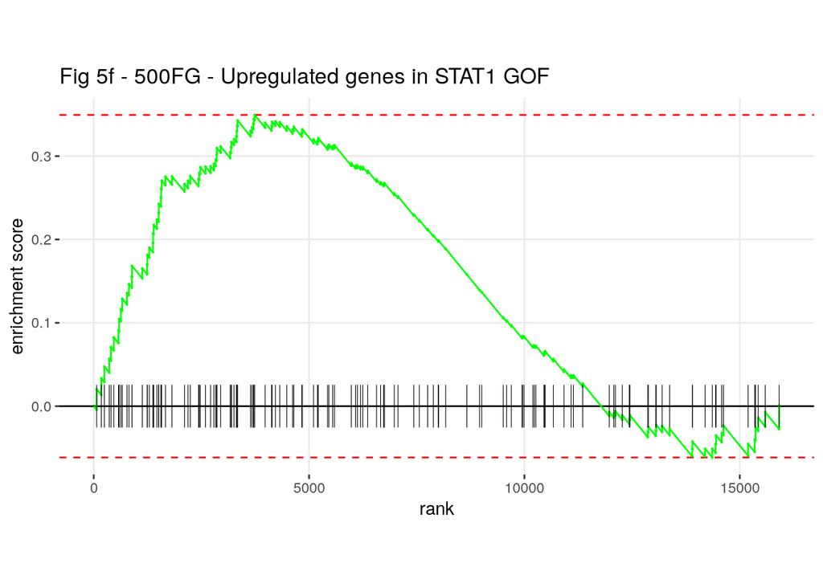

```r
plotEnrichment(DE_genes_list$up_4h_ctrl, -rank_gene_HuVa$FG500) +
  labs(title="Fig 5f - 500FG - Upregulated genes in STAT1 GOF") +
  theme(aspect.ratio = 1/2)
```

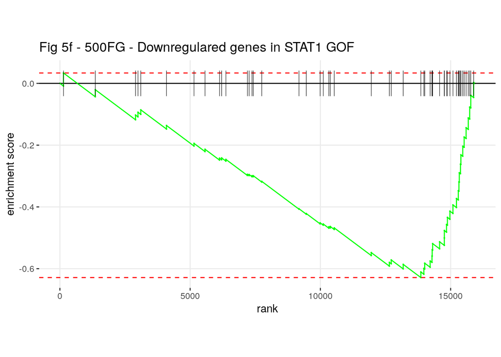

```r
plotEnrichment(DE_genes_list$dw_4h_ctrl, -rank_gene_HuVa$FG500) +
  labs(title="Fig 5f - 500FG - Downregulared genes in STAT1 GOF") +
  theme(aspect.ratio = 1/2)
```

#### 1.4.18.2 ImmVar Monocytes

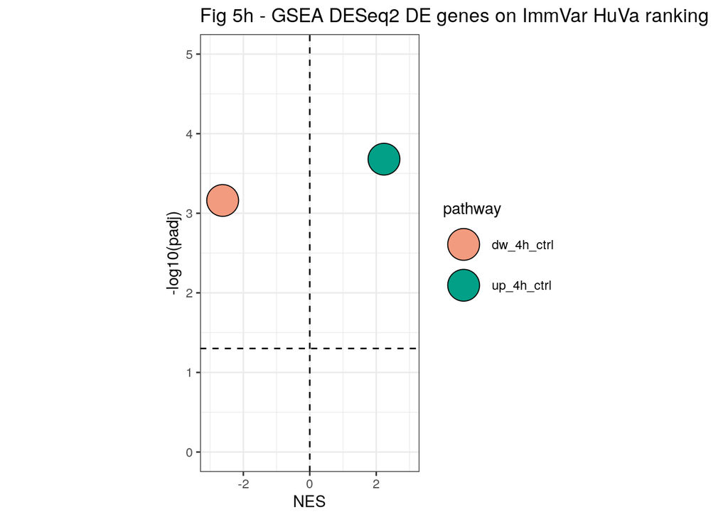

```r
ggplot(gsea_ImmVarM[c(1,2),], aes(x=NES, y=-log10(padj), fill=pathway)) +
  theme_bw() +
  geom_point(size=10, shape = 21) +
  theme(aspect.ratio = 2) +
  scale_x_continuous(limits = c(-3,3)) +
  scale_y_continuous(limits = c(0,5)) +
  geom_hline(yintercept = -log10(0.05), linetype="dashed") +
  geom_vline(xintercept = 0, linetype="dashed") +
  ggtitle("Fig 5h - GSEA DESeq2 DE genes on ImmVar HuVa ranking") +
  scale_fill_manual(values = c("#F39B7F", "#01A087"))
```

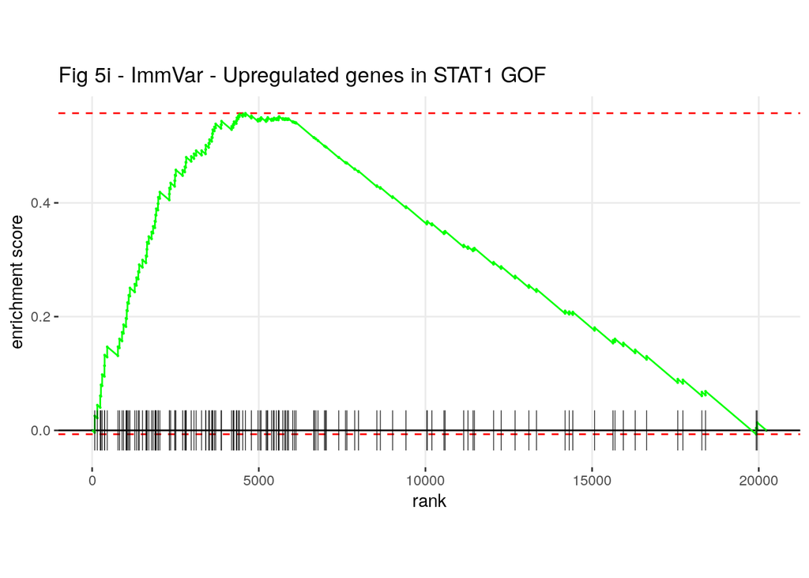

```r
plotEnrichment(DE_genes_list$up_4h_ctrl,
               -rank_gene_HuVa$ImmVarM) + labs(title="Fig 5i - ImmVar - Upregulated genes in STAT1 GOF") + theme(aspect.ratio = 1/2)
```

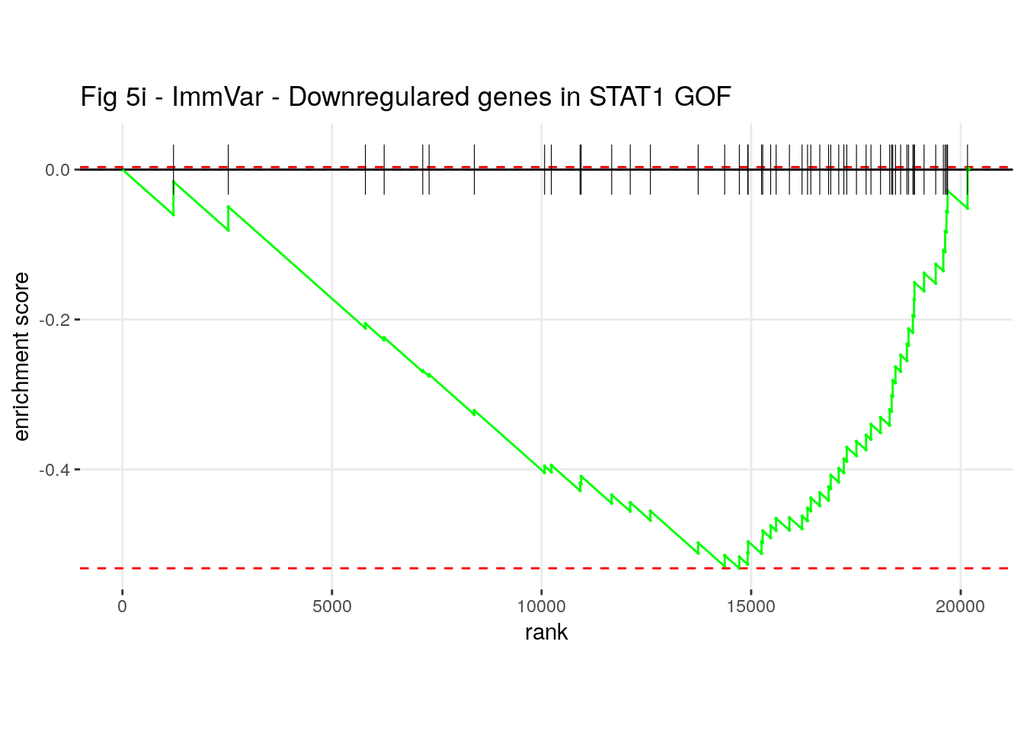

```r
plotEnrichment(DE_genes_list$dw_4h_ctrl,
               -rank_gene_HuVa$ImmVarM) + labs(title="Fig 5i - ImmVar - Downregulared genes in STAT1 GOF") + theme(aspect.ratio = 1/2)
```

## 1.5 STAT1 GOF - Sorted populations

### 1.5.1 Load data

```r
norm_anno_sorted <- readRDS("./data/STAT1_sort_norm_count.rds")
sample_table_sorted <- readRDS("./data/STAT1_sort_sample_table.rds")
```

### 1.5.2 Calculate the fold changes

```r
# First I change the name of the columns to make it easier to read

if (identical(colnames(norm_anno_sorted)[2:7], as.character(sample_table_sorted$ID))) {

  colnames(norm_anno_sorted)[2:7] <- sample_table_sorted$Merged

# Adding the columns with the FC
norm_anno_sorted$log2_FC_Tconv <- log2(norm_anno_sorted$D2_Tconv_mutant_unstim / norm_anno_sorted$D1_Tconv_wt_unstim)
norm_anno_sorted$log2_FC_CTL <- log2(norm_anno_sorted$D2_CTLs_mutant_unstim / norm_anno_sorted$D1_CTLs_wt_unstim)
norm_anno_sorted$log2_FC_Mono <- log2(norm_anno_sorted$D2_Mono_mutant_unstim / norm_anno_sorted$D1_Mono_wt_unstim)

} else {
  print("something wrong with the table")
}
```

### 1.5.3 Cleaning the data

```r
# separate the df for the visualization
FC_df <- norm_anno_sorted[ , c(1, 8, 12:14)]

# Removing the inf and NaN values and setting them to 0 - Those are coming when 1 or both genes in the comparison are equal to 0
FC_df$log2_FC_Tconv[is.infinite(FC_df$log2_FC_Tconv)] <- 0
FC_df$log2_FC_CTL[is.infinite(FC_df$log2_FC_CTL)] <- 0
FC_df$log2_FC_Mono[is.infinite(FC_df$log2_FC_Mono)] <- 0

FC_df$log2_FC_Tconv[is.na(FC_df$log2_FC_Tconv)] <- 0
FC_df$log2_FC_CTL[is.na(FC_df$log2_FC_CTL)] <- 0
FC_df$log2_FC_Mono[is.na(FC_df$log2_FC_Mono)] <- 0

rm(norm_anno_sorted, sample_table_sorted)
```

### 1.5.4 Preparing the data for visualization

```r
fc_cutoff <- 2

# Defining the datasets for plotting
order_Tconv <- FC_df[order(abs(FC_df$log2_FC_Tconv), decreasing = T), ] # order the data
order_Tconv$order <- seq(1:dim(order_Tconv)[1]) # Setting the order for plotting
order_Tconv$cell_type <- "T Conv" # Giving a name to the group
order_Tconv <- order_Tconv[, c(3, 6, 7)] # Filtering only the interesting colums
colnames(order_Tconv)[1] <- "FC" # harmonize the colnams

order_CTL <- FC_df[order(abs(FC_df$log2_FC_CTL), decreasing = T), ]
order_CTL$order <- seq(1:dim(order_CTL)[1])
order_CTL$cell_type <- "CTL"
order_CTL <- order_CTL[, c(4, 6, 7)]
colnames(order_CTL)[1] <- "FC"

order_Mono <- FC_df[order(abs(FC_df$log2_FC_Mono), decreasing = T), ]
order_Mono$order <- seq(1:dim(order_Mono)[1])
order_Mono$cell_type <- "Monocytes"
order_Mono <- order_Mono[, c(5, 6, 7)]
colnames(order_Mono)[1] <- "FC"

df <- rbind(order_Mono, order_Tconv, order_CTL)

rm(order_Mono, order_Tconv, order_CTL)

df$cell_type <- factor(df$cell_type, levels = c("Monocytes", "T Conv", "CTL"))

df_filter <- df[abs(df$FC) > fc_cutoff, ]

df_filter <- as.data.frame(table(df_filter$cell_type))
```

### 1.5.5 Plot

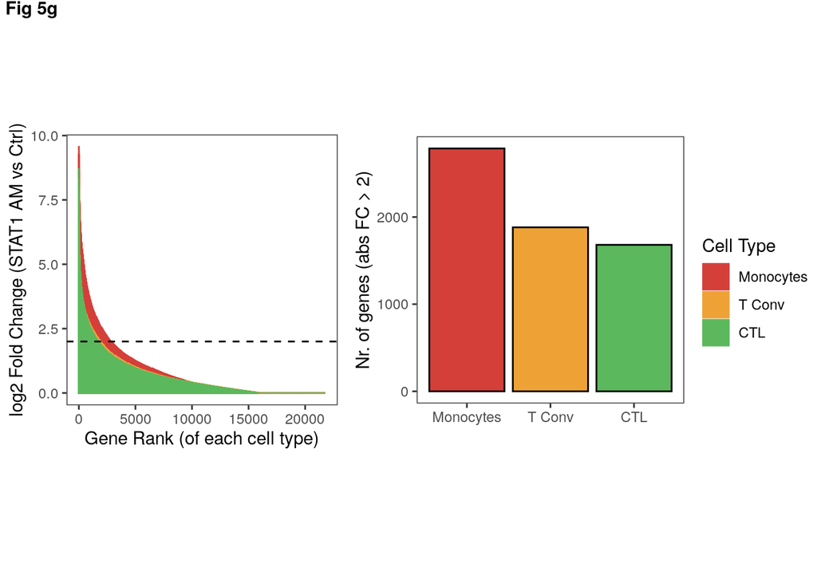

```r
# Single plots
p1 <- ggplot(df, aes(x = order, y = abs(FC), color = cell_type, fill = cell_type)) +
             geom_col(position = position_identity()) +
             theme_bw() +
             ylab("log2 Fold Change (STAT1 AM vs Ctrl)") +
             xlab("Gene Rank (of each cell type)") +
             labs(fill = "Cell Type", color = "Cell Type") +
             scale_color_locuszoom() +
             scale_fill_locuszoom() +
             theme(aspect.ratio = 1, panel.grid = element_blank()) +
             geom_hline(yintercept = fc_cutoff, linetype = "dashed", color = "black", size = 0.5)

p2 <- ggplot(df_filter, aes(x = Var1, y = Freq, fill = Var1)) +
             geom_bar(stat = "identity", color = "black") +
             scale_fill_locuszoom() +
             theme_bw() +
             theme(aspect.ratio = 1, panel.grid = element_blank()) +
             ylab("Nr. of genes (abs FC > 2)") +
             xlab("") +
             labs(fill = "Cell Type")

plot_arrange <- ggarrange(p1, p2, ncol = 2, vjust = 1, common.legend = TRUE, legend = "right")

annotate_figure(plot_arrange,
                fig.lab = "Fig 5g",
                fig.lab.face = "bold")
```

```r
rm(p1, p2, df_filter, df, plot_arrange)
```

# 2 Clean the environment

```r
source("./source/clean.R")
```

# 3 Session info

```r
info
```

# 4 Save environment

```r
save.image(paste("./data/",Sys.Date(), "_huva_Figure_5.RData", sep = ""))
```